# COVID-19 vaccines - tweets analysis

Collecting and Analyzing Big Data for Social Sciences [S0K17a], KU Leuven, Group 12

Jakub Cierocki, r0867514

Aleksandra Kotowicz, r0878531

Prabhjyoth Mattummal, r0861984

Academic year 2021-2022

# Overview

The rise of COVID-19 pandemic and further vaccines development raised concerns of people all around the world. The discussion was conducted through, among the other, social media, including the biggest platforms like Facebook or Twitter. Probably never before a single topic was so popular all around the globe at the same time. Unfortunately, this topic also significantly polarized global society as well as entailed the rise of misinformation, commonly simplified as “fake news”.

In this analysis we would like to focus on two aspects of that topic (research questions): 1. To what extent and how account characteristics explain people positive/negative attitude related to COVID-19 vaccines (sentiment analysis)? 2. What are the main subtopics disputed by people who engage in social media discussion about COVID-19-related matters?

The data was not anonymized, but as all those tweets are available publicly online it was not mandatory. Anyway in our research we will use neither account names nor descriptions as they contain many character of non-standard encoding or missing values so as provide not a lot of research value.

Because of the huge size of the dataset and GitHub file size limit we utilized Apache Arrow Parquet compressed binary data format which reduced our file size more than by factor of 3. So only that file will be available in the repository and utilized in further part of that research.

```r
# df <- read_csv("data/vaccination_all_tweets.csv", col_types = cols(id = col_character()))
# arrow::write_parquet(df, "data/vaccination_all_tweets.parquet", version = "2.0", compression = "lz4", compression_level = 20)

df <- arrow::read_parquet("data/vaccination_all_tweets.parquet")
head(df) |> kable(format = "pipe")
```

| id | user_name | user_location | user_description | user_created | user_followers | user_friends | user_favourites | user_verified | date | text | hashtags | source | retweets | favorites | is_retweet |
| --- | --- | --- | --- | --- | --- | --- | --- | --- | --- | --- | --- | --- | --- | --- | --- |
| 1340539111971516416 | Rachel Roh | La Crescenta-Montrose, CA | Aggregator of Asian American news; scanning diverse sources 24/7/365. RT’s, Follows and ‘Likes’ will fuel me 👩‍💻 | 2009-04-08 17:52:46 | 405 | 1692 | 3247 | FALSE | 2020-12-20 06:06:44 | Same folks said daikon paste could treat a cytokine storm #PfizerBioNTech https://t.co/xeHhIMg1kF | [‘PfizerBioNTech’] | Twitter for Android | 0 | 0 | FALSE |
| 1338158543359250433 | Albert Fong | San Francisco, CA | Marketing dude, tech geek, heavy metal & ’80s music junkie. Fascinated by meteorology and all things in the cloud. Opinions are my own. | 2009-09-21 15:27:30 | 834 | 666 | 178 | FALSE | 2020-12-13 16:27:13 | While the world has been on the wrong side of history this year, hopefully, the biggest vaccination effort we’ve ev… https://t.co/dlCHrZjkhm | NA | Twitter Web App | 1 | 1 | FALSE |
| 1337858199140118533 | eli🇱🇹🇪🇺👌 | Your Bed | heil, hydra 🖐☺ | 2020-06-25 23:30:28 | 10 | 88 | 155 | FALSE | 2020-12-12 20:33:45 | #coronavirus #SputnikV #AstraZeneca #PfizerBioNTech #Moderna #Covid_19 Russian vaccine is created to last 2-4 years… https://t.co/ieYlCKBr8P | [‘coronavirus’, ‘SputnikV’, ‘AstraZeneca’, ‘PfizerBioNTech’, ‘Moderna’, ‘Covid_19’] | Twitter for Android | 0 | 0 | FALSE |
| 1337855739918835717 | Charles Adler | Vancouver, BC - Canada | Hosting “CharlesAdlerTonight” Global News Radio Network. Weeknights 7 Pacific-10 Eastern - Email comments/ideas to charles@charlesadlertonight.ca | 2008-09-10 11:28:53 | 49165 | 3933 | 21853 | TRUE | 2020-12-12 20:23:59 | Facts are immutable, Senator, even when you’re not ethically sturdy enough to acknowledge them. (1) You were born i… https://t.co/jqgV18kch4 | NA | Twitter Web App | 446 | 2129 | FALSE |
| 1337854064604966912 | Citizen News Channel | NA | Citizen News Channel bringing you an alternative news source from citizen journalists that haven’t sold out. Real news & real views | 2020-04-23 17:58:42 | 152 | 580 | 1473 | FALSE | 2020-12-12 20:17:19 | Explain to me again why we need a vaccine @BorisJohnson @MattHancock #whereareallthesickpeople #PfizerBioNTech… https://t.co/KxbSRoBEHq | [‘whereareallthesickpeople’, ‘PfizerBioNTech’] | Twitter for iPhone | 0 | 0 | FALSE |
| 1337852648389832708 | Dee | Birmingham, England | Gastroenterology trainee, Clinical Research Fellow in IBD, mother to human and fur baby, Canadian in Britain | 2020-01-26 21:43:12 | 105 | 108 | 106 | FALSE | 2020-12-12 20:11:42 | Does anyone have any useful advice/guidance for whether the COVID vaccine is safe whilst breastfeeding?… https://t.co/EifsyQoeKN | NA | Twitter for iPhone | 0 | 0 | FALSE |

```r
NA
```

# Question 1: Sentiment analysis

## Labeling sentiment using BERT

Sentiment analysis is very common task among Natural Language Processing topics. Although it is itself a supervised learning problem requiring availability of target variable expressing sentiment which is not the case of our dataset. So as we decided to utilize pre-trained *BERTweet* Neural Network (Transformer) model, fine-tuned for sentiment analysis to obtain predicted sentiments based on pure text, then explain them using other features in a statistical, supervised fashion. The model, named `finiteautomata/bertweet-base-sentiment-analysis` was retrieved from *Hugging Face* repository, containing many pre-trained transformers, see (Pérez et el., 2021). As *Hugging Face* does not deliver *R* API at all, and the *torch* (neural network library required to obtain predictions) one is still immature we decided to call of them in *R* using `reticulate` package.

```r
device <- ifelse(
  torch$cuda$is_available(),
  "cuda:0",
  "cpu"
)

tokenizer <- transformers$AutoTokenizer$from_pretrained(
  "finiteautomata/bertweet-base-sentiment-analysis",
  normalization = TRUE
)
```

```r
model <- transformers$AutoModelForSequenceClassification$from_pretrained("finiteautomata/bertweet-base-sentiment-analysis")$to(device)
```

```r
pipeline <- transformers$TextClassificationPipeline(
  model = model,
  tokenizer = tokenizer,
  device = ifelse(device == "cpu", -1L, 0L),
  top_k = 1L
)
```

```r
df_sentiment <- pipeline(df$text) |>
  map_dfr(~ .x[[1]]) |>
  mutate(
    sentiment = as.factor(label) |> `levels<-`(list(
        "Positive" = "POS",
        "Negative" = "NEG",
        "Neutral" = "NEU"
      )),
    .before = 1
  ) |>
  select(-label)
```

The standard approach for neural-based sentiment classifiers is to consider 3 different class: Positive, Negative and Neutral. In classical Logistic Regression we require two classes, so as we decided to drop the most numerous, Neutral class which itself reduced noise by a lot, still preserving more than sufficient amount of observations (around 49k). They are models enabling statistical inference on multinomial target, like Probit model or modified Logit one but we decided not to utilize them as they make interpretation of the parameters less straightforward also being significantly more computationaly expensive which is an issue regarding a size of available data.

```r
df <- bind_cols(df, df_sentiment)

df |>
  arrow::write_parquet(
    "data/vaccination_all_tweets.parquet",
    version = "2.0",
    compression = "lz4",
    compression_level = 20
  )
```

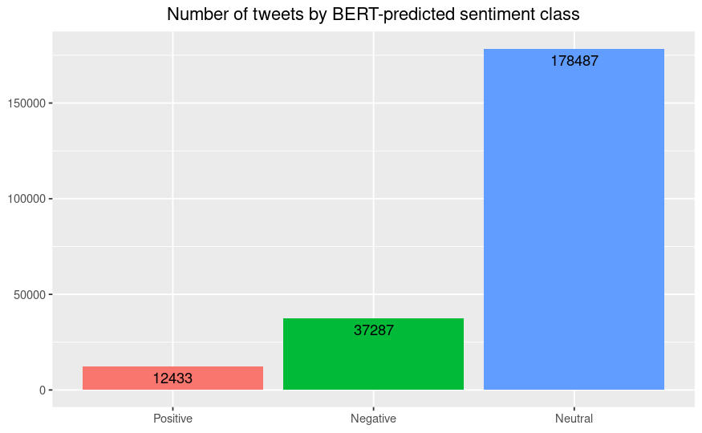

```r
df |>
  count(sentiment) |>
  ggplot(aes(x = sentiment, y = n, fill = sentiment)) +
  geom_col() +
  geom_text(aes(label = as.character(n)), vjust = 1.5) +
  labs(x = NULL, y = NULL, title = "Number of tweets by BERT-predicted sentiment class") +
  theme(legend.position = "none", plot.title = element_text(hjust = 0.5))
```

## Data wrangling

In order to reduce amount of dummies and simplify model interpretation we combined iPhone’s and iPad’s into single level, as well as putting all minor sources into one, reference class “Other”. Hashtags get cleaned and normalized. Variable “is_retweet” is probably corrupted, because contains onfly single value “FALSE” and so as was dropped. Finally datetime features get converted to *integer* expressing number of days since fixed point of time, respectively minimum value for account creation and beginning of the pandemic for tweet publish date.

```r
df <- arrow::read_parquet("data/vaccination_all_tweets.parquet")

print(any(df$is_retweet)) # feature to be removed
```

```
[1] FALSE
```

```r
minor_tweets_sources <- df$source |>
  unique() |>
  na.omit() |>
  discard(~ .x %in% c(
    "Twitter for iPhone",
    "Twitter for Android",
    "Twitter Web App",
    "Twitter for iPad",
    "TweetDeck",
    "Instagram"
  )) |>
  c("NA")

df <- df |>
  select(-is_retweet) |>
  mutate(
    source = ifelse(is.na(source), "NA", source) |>
      as.factor() |>
      forcats::fct_collapse(
        "Twitter for iPhone/iPad" = c("Twitter for iPhone", "Twitter for iPad"),
        "Other" = minor_tweets_sources
      ) |>
      relevel(ref = "Other"),
    account_age_days = as_date(user_created) |> as.integer(),
    days_since_2019 = as.integer(as_date(date) - ymd("2019-12-31")),
    hashtags = hashtags |>
      str_extract("(?<=^\\[).*(?=\\]$)") |>
      str_remove_all("ー") |>
      str_extract_all("(?<=').*?(?=[',\\s])") |>
      map(
        ~ str_to_lower(.x[.x != ""]) |>
          str_remove_all("[:punct:]") |>
          unique()
      )
  ) |>
  mutate(
    account_age_days = account_age_days - min(account_age_days)
  )

df |> select(id, source, account_age_days, days_since_2019, hashtags) |> head()
```

| id | source | account_age_days | days_since_2019 | hashtags |
| --- | --- | --- | --- | --- |
| 1340539111971516416 | Twitter for Android | 998 | 355 |  |
| 1338158543359250433 | Twitter Web App | 1164 | 348 |  |
| 1337858199140118533 | Twitter for Android | 5094 | 347 |  |
| 1337855739918835717 | Twitter Web App | 788 | 347 |  |
| 1337854064604966912 | Twitter for iPhone/iPad | 5031 | 347 |  |
| 1337852648389832708 | Twitter for iPhone/iPad | 4943 | 347 |  |

```r
NA
```

```r
df_inference <- df |>
  select(id, user_followers, user_friends, user_favourites, user_verified, hashtags, source, retweets, favorites, account_age_days, days_since_2019, sentiment, score) |>
  filter(sentiment %in% c("Positive", "Negative"))

all_hashtags <- df_inference$hashtags |>
  as.list() %>%
  do.call(c, .) |>
  table() |>
  sort(decreasing = TRUE)

print(sum(all_hashtags))
```

```
[1] 101976
```

```r
top_popular_hashtags <- all_hashtags |> head(25)

print(top_popular_hashtags)
```

```
          moderna           covaxin           covid19            pfizer           vaccine          sputnikv           sinovac      covidvaccine    pfizerbiontech             covid        vaccinated       astrazeneca
            15949              8806              6441              4385              3741              2139              2133              1979              1892              1667              1438              1086
         vaccines         sinopharm oxfordastrazeneca       coronavirus        covishield       vaccination    covid19vaccine             india     getvaccinated          breaking johnsonandjohnson               who
             1069              1013               991               990               990               854               666               568               548               452               444               441
     deltavariant
              433
```

```r
df_hashtags_dummy <- top_popular_hashtags |>
  names() |>
  map_dfc(~ {
    hashtag <- .
    tibble(
      !!sprintf("hashtag_%s", hashtag) := df_inference$hashtags |> map_lgl(~ hashtag %in% .x)
    )
  })

df_inference <- bind_cols(df_inference, df_hashtags_dummy)

head(df_hashtags_dummy)
```

| hashtag_moderna | hashtag_covaxin | hashtag_covid19 | hashtag_pfizer | hashtag_vaccine | hashtag_sputnikv | hashtag_sinovac | hashtag_covidvaccine | hashtag_pfizerbiontech | hashtag_covid | hashtag_vaccinated | hashtag_astrazeneca | hashtag_vaccines | hashtag_sinopharm | hashtag_oxfordastrazeneca | hashtag_coronavirus | hashtag_covishield | hashtag_vaccination | hashtag_covid19vaccine | hashtag_india | hashtag_getvaccinated | hashtag_breaking | hashtag_johnsonandjohnson | hashtag_who | hashtag_deltavariant |
| --- | --- | --- | --- | --- | --- | --- | --- | --- | --- | --- | --- | --- | --- | --- | --- | --- | --- | --- | --- | --- | --- | --- | --- | --- |
| FALSE | FALSE | FALSE | FALSE | FALSE | FALSE | FALSE | FALSE | TRUE | FALSE | FALSE | FALSE | FALSE | FALSE | FALSE | FALSE | FALSE | FALSE | FALSE | FALSE | FALSE | FALSE | FALSE | FALSE | FALSE |
| FALSE | FALSE | FALSE | FALSE | FALSE | FALSE | FALSE | FALSE | FALSE | FALSE | FALSE | FALSE | FALSE | FALSE | FALSE | FALSE | FALSE | TRUE | FALSE | FALSE | FALSE | FALSE | FALSE | FALSE | FALSE |
| FALSE | FALSE | FALSE | FALSE | FALSE | FALSE | FALSE | FALSE | FALSE | FALSE | FALSE | FALSE | FALSE | FALSE | FALSE | FALSE | FALSE | FALSE | FALSE | FALSE | FALSE | FALSE | FALSE | FALSE | FALSE |
| FALSE | FALSE | FALSE | FALSE | TRUE | FALSE | FALSE | FALSE | TRUE | FALSE | FALSE | FALSE | FALSE | FALSE | FALSE | FALSE | FALSE | FALSE | FALSE | FALSE | FALSE | FALSE | FALSE | FALSE | FALSE |
| FALSE | FALSE | TRUE | FALSE | FALSE | FALSE | FALSE | FALSE | TRUE | FALSE | FALSE | FALSE | FALSE | FALSE | FALSE | FALSE | FALSE | FALSE | FALSE | FALSE | FALSE | FALSE | FALSE | FALSE | FALSE |
| FALSE | FALSE | FALSE | FALSE | FALSE | FALSE | FALSE | FALSE | TRUE | FALSE | FALSE | FALSE | FALSE | FALSE | FALSE | TRUE | FALSE | FALSE | FALSE | FALSE | FALSE | FALSE | FALSE | FALSE | FALSE |

## Feature transformations

```r
df_inference |> select(-score, -id) |> map_lgl(is.numeric) |> sum() |> print()
```

```
[1] 7
```

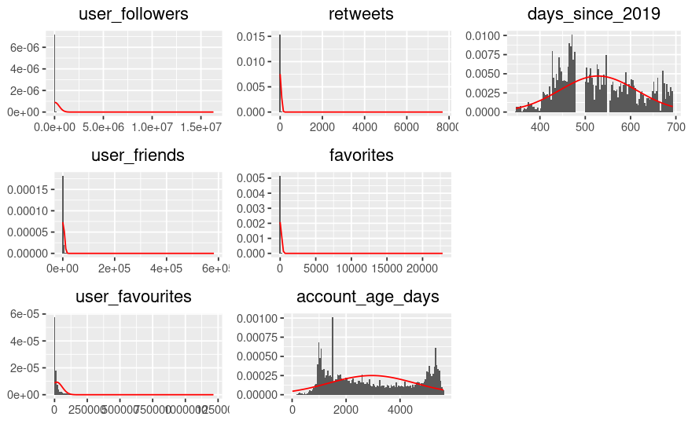

```r
df_inference |>
  select(where(is.numeric), -score, -id) |>
  histogram_grid()
```

We conclude that log-transformation is required for: *user_followers*, *user_friends*, *user_favourites*, *retweets*, *favorites*, as all those variables are right-skewed with heavy-tail, which is the case regarding Log-Normal distribution.

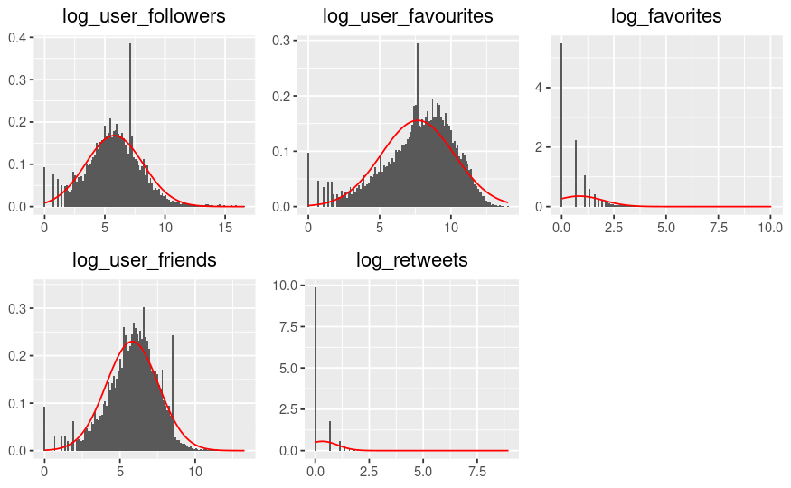

```r
heavy_tailed_features <- c("user_followers", "user_friends", "user_favourites", "retweets", "favorites")

df_inference2 <- df_inference |>
  mutate(across(all_of(heavy_tailed_features), ~ log(.x + 1))) |>
  rename_with(~ sprintf("log_%s", .x), all_of(heavy_tailed_features))

df_inference2 |>
  select(all_of(sprintf("log_%s", heavy_tailed_features))) |>
  histogram_grid()
```

Indeed, log-transformations improved distributions for 3 account statistics, making them much more similar to Normal. Unfortunately, due to a lot of mass at 0, it does not work for tweet statistics, respectively: *favorites* and *retweets*. For simiplificity all those variables are gonna be included in final models in log-transformed form.

## Logit model estimation and evaluation

We decided to also add squares of both our time variables, as the relation with them in linear models is commonly expected to be quadratic or in general non-linear.

```r
options(scipen = 5)

logit_m1 <- df_inference2 |>
  select(-id, -hashtags, -score) |>
  mutate(sentiment = sentiment |> relevel(ref = "Negative")) |>
  mutate(across(where(is.logical), as.integer)) %>%
  glm(sentiment ~ . + I(account_age_days^2) + I(days_since_2019^2), family = binomial(link = "logit"), data = .)

summary(logit_m1)
```

```
Call:
glm(formula = sentiment ~ . + I(account_age_days^2) + I(days_since_2019^2),
    family = binomial(link = "logit"), data = .)

Deviance Residuals:
    Min       1Q   Median       3Q      Max
-2.3634  -0.7533  -0.5358   0.3144   3.4929

Coefficients:
                                     Estimate      Std. Error z value Pr(>|z|)
(Intercept)                    1.701918559519  0.480005467892   3.546 0.000392 ***
log_user_followers            -0.139638214488  0.008577185803 -16.280  < 2e-16 ***
log_user_friends               0.120305388643  0.010137496169  11.867  < 2e-16 ***
log_user_favourites           -0.013347990419  0.006048199721  -2.207 0.027319 *
user_verified                  0.251456827656  0.071907409181   3.497 0.000471 ***
sourceInstagram                1.426921146651  0.115874846792  12.314  < 2e-16 ***
sourceTweetDeck               -0.800486114807  0.143016011976  -5.597 2.18e-08 ***
sourceTwitter for Android      0.118858067477  0.083378169688   1.426 0.154004
sourceTwitter for iPhone/iPad  0.041797057758  0.082676147581   0.506 0.613171
sourceTwitter Web App         -0.337423537329  0.083430007900  -4.044 5.25e-05 ***
log_retweets                  -0.709354787699  0.023219332686 -30.550  < 2e-16 ***
log_favorites                  0.755935948703  0.014429380130  52.389  < 2e-16 ***
account_age_days               0.000169365286  0.000040072733   4.226 2.37e-05 ***
days_since_2019               -0.009536484594  0.001768363126  -5.393 6.94e-08 ***
hashtag_moderna               -0.081001702900  0.030030974315  -2.697 0.006991 **
hashtag_covaxin                0.073423308208  0.033520938276   2.190 0.028497 *
hashtag_covid19               -0.614409456966  0.043879836212 -14.002  < 2e-16 ***
hashtag_pfizer                -1.048577732178  0.064022301230 -16.378  < 2e-16 ***
hashtag_vaccine               -0.278736082350  0.052662964273  -5.293 1.20e-07 ***
hashtag_sputnikv               0.324208536474  0.054733857768   5.923 3.15e-09 ***
hashtag_sinovac                0.265319475919  0.055815959132   4.753 2.00e-06 ***
hashtag_covidvaccine          -0.229721523753  0.060855396677  -3.775 0.000160 ***
hashtag_pfizerbiontech         0.796406531999  0.057745129850  13.792  < 2e-16 ***
hashtag_covid                 -0.757042947245  0.092886010889  -8.150 3.63e-16 ***
hashtag_vaccinated            -0.120546402972  0.067447998253  -1.787 0.073897 .
hashtag_astrazeneca           -0.535057731282  0.106186488798  -5.039 4.68e-07 ***
hashtag_vaccines              -1.012874957115  0.140331351856  -7.218 5.29e-13 ***
hashtag_sinopharm             -0.174336362005  0.082882801617  -2.103 0.035430 *
hashtag_oxfordastrazeneca      0.106365827118  0.075928438967   1.401 0.161253
hashtag_coronavirus           -1.530175247072  0.169248076838  -9.041  < 2e-16 ***
hashtag_covishield            -0.951945419032  0.107045561795  -8.893  < 2e-16 ***
hashtag_vaccination           -0.295498086665  0.102261163875  -2.890 0.003857 **
hashtag_covid19vaccine        -0.091533301667  0.097646226478  -0.937 0.348554
hashtag_india                  0.213718661706  0.114717790186   1.863 0.062463 .
hashtag_getvaccinated         -0.181389368286  0.107056418624  -1.694 0.090202 .
hashtag_breaking              -4.184381072853  0.710232003167  -5.892 3.83e-09 ***
hashtag_johnsonandjohnson     -0.718044108267  0.206542999844  -3.476 0.000508 ***
hashtag_who                   -0.306497266388  0.135115693553  -2.268 0.023304 *
hashtag_deltavariant          -2.222200338088  0.308241018830  -7.209 5.62e-13 ***
I(account_age_days^2)         -0.000000031650  0.000000006332  -4.998 5.79e-07 ***
I(days_since_2019^2)           0.000006937270  0.000001639197   4.232 2.32e-05 ***
---
Signif. codes:  0 ‘***’ 0.001 ‘**’ 0.01 ‘*’ 0.05 ‘.’ 0.1 ‘ ’ 1

(Dispersion parameter for binomial family taken to be 1)

    Null deviance: 55925  on 49719  degrees of freedom
Residual deviance: 48034  on 49679  degrees of freedom
AIC: 48116

Number of Fisher Scoring iterations: 7
```

```r
acc_insample <- sum(round(logit_m1$fitted.values + 1) == as.integer(logit_m1$data$sentiment)) / nrow(logit_m1$data)

sprintf("Total number of significant coefficients assuming alpha = 0.05: %s\n", sum(summary(logit_m1)$coef[, "Pr(>|z|)"] < 0.05)) |> cat()
```

```
Total number of significant coefficients assuming alpha = 0.05: 34
```

```r
sprintf("Accuracy in-sample: %f\n\n", acc_insample) |> cat()
```

```
Accuracy in-sample: 0.774236
```

```r
DescTools::PseudoR2(logit_m1, which = "all")
```

```
       McFadden     McFaddenAdj        CoxSnell      Nagelkerke   AldrichNelson VeallZimmermann           Efron McKelveyZavoina            Tjur             AIC             BIC          logLik         logLik0
      0.1411069       0.1396407       0.1467626       0.2173348       0.1369768       0.2587554       0.1546941       0.2989232       0.1552238   48115.7654447   48477.1461091  -24016.8827223  -27962.5987446
             G2
   7891.4320446
```

Logistic regression performed surprisingly well in our scenario. We obtained model with 77% in-sample accuracy and 34 significant coefficients assuming $\alpha = 0.05$. We do not need to evaluate residuals distribution as CLT guarantees enough statistical power for t-tests thanks to huge number of observations. As number of variables and coefficient is large we decided to only briefly introduce most interesting conclusions instead of mechanically interpreting all coefficient estimates in statistical fashion:

1. Users of TweetDeck and Web App tend to post about vaccinates with negative sentiment, opposite for Instagram. We can state Hypothesis that is related to user age as Instagram is very popular among the youngest while Web App and especially TweetDeck are preferred by older generations.
2. Posting about COVID-19 vaccines with positive sentiment usually results in a lot of “likes” while negative tone is related to large number of “retweets”.
3. Presence of hashtags usually causes negative sentiment, especially when mentioned “breaking” (breaking news), “deltavariant”, “coronavirus”, “vaccines” and “pfizer”.
4. Verified user tend to post tweets of slightly more positive sentiment.
5. All 4 time related variables coefficients are significant regardless of their low values. Thanks to very large dataset standard error were low so as even features with very low impact could got marked as significant.

# Topic modelling

In this chapter we will try to evaluate the 2nd research question stated in Introduction - can we extract some common topics repeating between the tweets? In order to verify this statement we will utilize *Latent Dirichlet Allocation* bayesian model which originates from a bio-science but then start being applied as substitute of clustering methods, see (Blei et el., 2003). To ensure getting precise estimates we utilized Gibbs sampler instead of default Variational Inference-based methods which can produced biased results for smaller samples.

## Data wrangling

The data got transformed using `spacyr`, `quanteda` and `tidytext` *R* libraries to obtain a form of “Document Term Matrix” required by LDA. Tokens other than alphanumeric or containing pure numbers were removed, as well as stop words (taken package `SnowballC`) and parts-of-speech do not containing sentiment-relevant information. Finally we applied BiGram model, considering additional 2-word sequences along with single-word tokens. We decided not to consider n-grams for $n > 2$ as tweets are by definition short and we already removed typically non-informative terms.

```r
stopwords_df <- get_stopwords()

doc_feature_mat <- df |>
  select(id, text) |>
  rename(doc_id = id) |>
  spacy_parse(entity = FALSE, additional_attributes = c("is_punct", "like_url", "is_digit", "is_space")) |>
  filter(
    !is_punct,
    !like_url,
    !is_digit,
    !is_space,
    !(pos %in% c("AUX", "DET", "ADP", "NUM", "PUNCT")),
    str_length(lemma) > 1,
    !str_detect(lemma, "^[:punct:]s$")
  ) |>
  mutate(
    token = str_remove(token, "^\\."),
    lemma = str_remove(lemma, "^\\.")
  ) |>
  select(-is_punct, -like_url, -is_digit, -is_space) |>
  anti_join(stopwords_df, by = c("token" = "word")) |>
  anti_join(stopwords_df, by = c("lemma" = "word")) |>
  as.tokens(use_lemma = TRUE) |>
  tokens_ngrams(n = 1L:2L, concatenator = "+") |>
  dfm()

doc_feature_mat |> write_rds("data/dfm.rds", compress = "bz2")

topfeatures(doc_feature_mat)
```

```
covaxin vaccine moderna    dose     age    slot     get covid19  pfizer    bbmp
  76139   69633   50626   43061   27335   25060   22530   19382   15528   14206
```

For information purpose we present TOP250 most popular tokens in a form of Word Cloud plot.

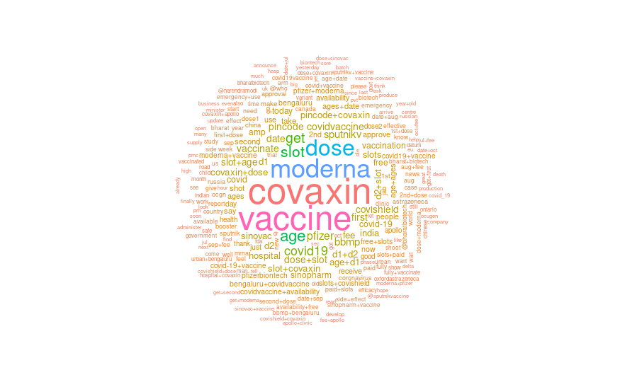

```r
doc_feature_mat |> textplot_wordcloud(color = scales::hue_pal()(250), max_words = 250)
```

It can be seen that the most used term is “covaxin”, which is an Indian vaccine. It may suggest that a lot of people who posted tweets were from India or had a connection to this country. The next most used word is “vaccine”, which is not surprising when it comes to COVID-19 as the vaccine topic was highly popular on social media. The third place is “moderna”, which is a well-known vaccine across USA and Europe. The next words, like “dose”, “age”, or “slot”, may be connected with people who wanted as well share or get some practical information regarding COVID-19 vaccine.

To simplify computations and reduce noise we decided to filter all n-grams being present in less than $0.1\%$ of given dataset.

```r
doc_term_mat <- doc_feature_mat |>
  dfm_trim(min_termfreq = 0.001, termfreq_type = "prop") |>
  convert(to = "topicmodels")

# doc_term_mat |> write_rds("data/dtm.rds", compress = "bz2")

doc_term_mat
```

```
<<DocumentTermMatrix (documents: 217745, terms: 89)>>
Non-/sparse entries: 967614/18411691
Sparsity           : 95%
Maximal term length: 25
Weighting          : term frequency (tf)
```

## Model

To further simplify and make us able to provide some logical interpretations for obtained clusters we decided to restrict LDA to only 8 topics. Computations were done with fixed side for the purpose of reproducibility.

```r
lda_mod <- doc_term_mat |> LDA(
  k = 8L,
  method = "Gibbs",
  controls = list(seed = 1234)
)
lda_results_df <- tidy(lda_mod, matrix = "beta")

print(lda_results_df$term |> unique())
```

```
 [1] "say"                       "pfizerbiontech"            "year"                      "vaccination"               "coronavirus"               "sputnikv"                  "astrazeneca"
 [8] "moderna"                   "vaccine"                   "need"                      "covid"                     "day"                       "good"                      "get"
[15] "covidvaccine"              "covid19"                   "people"                    "first"                     "new"                       "health"                    "receive"
[22] "vaccinate"                 "amp"                       "approve"                   "now"                       "make"                      "go"                        "approval"
[29] "use"                       "pfizer"                    "mrna"                      "covid-19"                  "covid19+vaccine"           "covid-19+vaccine"          "take"
[36] "dose"                      "moderna+vaccine"           "shot"                      "thank"                     "just"                      "first+dose"                "today"
[43] "hospital"                  "1st"                       "age"                       "free"                      "india"                     "2nd"                       "sinovac"
[50] "jab"                       "second"                    "pfizer+moderna"            "russia"                    "china"                     "date"                      "sinopharm"
[57] "dose1"                     "booster"                   "sputnik"                   "covaxin"                   "covishield"                "availability"              "@bharatbiotech"
[64] "fee"                       "slot"                      "ocgn"                      "dose2"                     "d1"                        "covaxin+dose"              "slots"
[71] "apollo"                    "bengaluru"                 "slot+covaxin"              "pincode"                   "ages"                      "bbmp"                      "dose+slot"
[78] "slot+age"                  "d2"                        "d1+d2"                     "age+d1"                    "d2+slot"                   "bengaluru+covidvaccine"    "covidvaccine+availability"
[85] "free+slots"                "slots+covishield"          "pincode+covaxin"           "age+ages"                  "ages+date"
```

```r
lda_results_df
```

| topic | term | beta |
| --- | --- | --- |
| 1 | say | 0.0000008500011 |
| 2 | say | 0.0000260714745 |
| 3 | say | 0.0504559969792 |
| 4 | say | 0.0000152506665 |
| 5 | say | 0.0000008297110 |
| 6 | say | 0.0155015251487 |
| 7 | say | 0.0000008233644 |
| 8 | say | 0.0000006817613 |
| 1 | pfizerbiontech | 0.0000008500011 |
| 2 | pfizerbiontech | 0.0000008410153 |

[output cut: 702 more lines]

```r
NA
```

## Evaluation

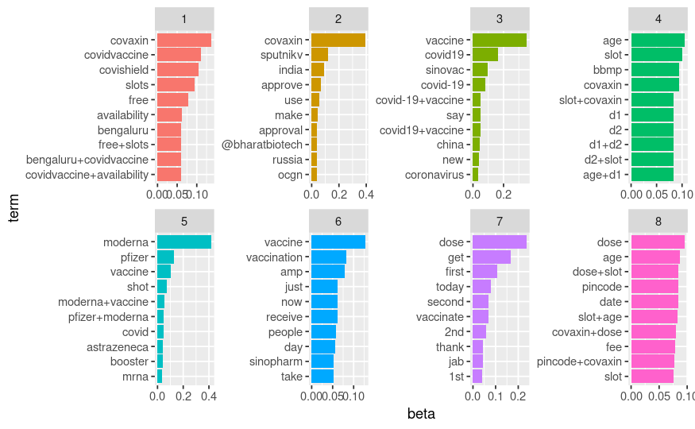

```r
lda_results_by_topic_df <- lda_results_df |>
  group_by(topic) |>
  slice_max(beta, n = 10) |>
  ungroup() |>
  arrange(topic, -beta)

lda_results_by_topic_df |>
  mutate(term = reorder_within(term, beta, topic)) |>
  ggplot(aes(beta, term, fill = factor(topic))) +
  geom_col(show.legend = FALSE) +
  scale_x_continuous(n.breaks = 3) +
  facet_wrap(~ topic, scales = "free", ncol = 4) +
  scale_y_reordered()
```

We can see that the topics are visibly different from each other. We propose such an interpretation for each of them.

1. Vaccine availability: Availability of all kinds COVID-19 vaccines in Bengaluru, India.
2. Vaccination in India: This group appears to be the most consistent with search phrases.
3. Vaccination in China: Both “sinovac” and “china” terms present.
4. Vaccination in Bengaluru: Provided by the governmental organisation Bruhat Bengaluru Mahanagara Palike (BBMP)
5. Vaccines from Europe and United States: Terms connected to Moderna, Pfizer and Astra-Zeneca vaccines.
6. Vaccine slogans: Slogans for advertising and encouraging to get the jab.
7. General post-vaccination experience: General terms related to getting vaccinated recently like “today”, “thank”.
8. Practical information: Information regarding doses, fees, slots, dates.

A worth noticing fact is that majority of those topics are related to specific geographic areas.

# Summary and conclusions

This proven that theoretically very noisy data scraped/collected from social networks case be useful for the purpose of verifying hypothesizes or exploring people’s interests. Many logical or even less obvious hypothesis were positively evaluated in inference part of our analysis. It was very surprising how strongly were the text and other user/tweet characteristics related. In terms of topics modelling, the surprising results for us was that topics are so strongly binned to specific geographic areas.

# Limitations

We experienced some limitations while conducting this analysis. First, in the dataset, some of the tweets texts were cut, causing information loss. Moreover lack of computational power was sometime a limitation, due to the size of dataset and nature of unstructured data which is in general very demanding in those terms. *R* itself was limiting us a lot, as its’ NLP package ecosystem is significantly less matured comparing to *Python* one as well us amount of learning materials is more limited. Moreover, in *R* package ecosystem is more distributed and still many packages like i.e. `quanteda` do not follow *tidydata* coding and design principals. Finally Fisher-originated approach to statistical inference, relaying heavily on $p$-values, is not well suited for huge, computationally generated datasets. In further research, bayesian approach seems worth trying.

# Elevator pitch

Our study focuses on the analysis of tweets related to COVID-19 vaccines that we obtained from [kaggle.com](https://www.kaggle.com/datasets/gpreda/all-covid19-vaccines-tweets). We were looking for the answers to two questions: To what extent and how account and tweet characteristics explain people positive/negative attitude related to COVID-19 vaccines? and What are the main subtopics disputed by people who engage in social media discussion about COVID-19-related matters?

In our research we used *GNU R* and various ML and statistical libraries inc. `transformers`, `pytorch`, `spacyr`, `quanteda` and `tidytext`.

We found out that indeed account and tweet characteristics explain the tweet predicted sentiment well as well as there are some clearly separable topics among the tweets with nice, hypothetical interpretations.

# References

1. Juan M. Pérez, Juan C. Giudici, Franco Luque. 2021. pysentimiento: A Python Toolkit for Sentiment Analysis and SocialNLP tasks. arXiv. 2106.09462.
2. David M. Blei, Andrew Y. Ng, and Michael I. Jordan. 2003. Latent dirichlet allocation. J. Mach. Learn. Res. 3, null (3/1/2003), 993–1022.